# Scratch Pad

Bryan Johns

2025-02-26

## Scratch Pad for Cyclistic Data Analysis

Exploratory Data Analysis, unencumbered by the need to be **too** presentable.

```r
# Load the data, combine into a df
q1_2019 = read.csv("./resources/data/q1_2019_cleaned.csv")
q2_2019 = read.csv("./resources/data/q2_2019_cleaned.csv")
q3_2019 = read.csv("./resources/data/q3_2019_cleaned.csv")
q4_2019 = read.csv("./resources/data/q4_2019_cleaned.csv")
stations = read.csv("./resources/data/stations.csv")
# q1_2020 = read.csv("./resources/data/q1_2020_cleaned.csv")

# 2020 data contains chars in ride_id and rideable_type
# convert_columns_to_character <- function(df) {
#   df <- mutate(df,
#                ride_id = as.character(ride_id),
#                rideable_type = as.character(rideable_type))
#   return(df)
# }

# Apply the function to each quarter's data frame
# q1_2019 <- convert_columns_to_character(q1_2019)
# q2_2019 <- convert_columns_to_character(q2_2019)
# q3_2019 <- convert_columns_to_character(q3_2019)
# q4_2019 <- convert_columns_to_character(q4_2019)

# df <- bind_rows(q1_2019, q2_2019, q3_2019, q4_2019, q1_2020)
df <- bind_rows(q1_2019, q2_2019, q3_2019, q4_2019)
```

Number of member vs casual rides

```r
table(df$member_casual)
```

```
##
##  casual  member
##  880631 2937360
```

3 million member rides vs 1 million casual rides. Unfortunately, there is no way to tell how many are repeat users. Presumably, many member riders repeat far more often than casual riders.

In the scenario, and in real life, the data is shared without any sort of identifying information that would help track that, probably why after 2019 they removed gender and birthyear.

!!NOTE!! - Below is where I realized that ride_length was in minutes for 2019, seconds for 2020, and had to adjust data cleaning. It has been rectified.

```r
summary(df$ride_length)
```

```
##      Min.   1st Qu.    Median      Mean   3rd Qu.      Max.
##      1.02      6.85     11.82     24.17     21.40 177200.37
```

There are some ridiculously long rides.

```r
max(df$ride_length)/60/24
```

```
## [1] 123.0558
```

123 days! Hell of an outlier.

```r
print(df[which.max(df$ride_length), ])
```

```
##             X  ride_id          started_at            ended_at rideable_type
## 148898 148898 21920842 2019-02-14 14:44:13 2019-06-17 16:04:35          3846
##        start_station_id     start_station_name end_station_id
## 148898              213 Leavitt St & North Ave            360
##                   end_station_name member_casual gender birthyear       date
## 148898 DIVVY Map Frame B/C Station        casual   <NA>        NA 2019-02-14
##        month day year day_of_week season hour ride_length start_lat start_lng
## 148898     2  14 2019    Thursday Winter   14    177200.4   41.9102  -87.6823
##        end_lat end_lng
## 148898      NA      NA
```

```r
# ggplot(df, aes(y = ride_length)) +
#   geom_boxplot() +
#   labs(title = "Boxplot of Ride Lengths",
#        y = "Ride Length (minutes)",
#        x = "") +
#   theme_minimal()
```

Kinda pointless to plot that.

## Rides by Member type (total rides, duration)

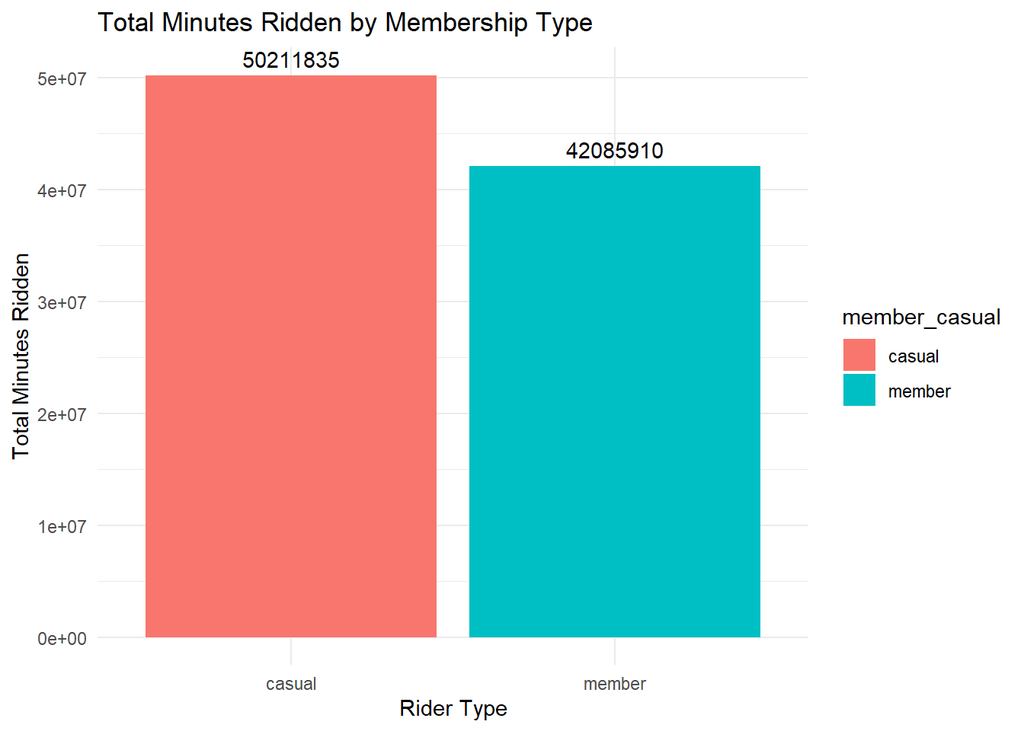

```r
# sum total ride length by membership type
total_minutes_ridden <- df %>%
  group_by(member_casual) %>%
  summarise(total_minutes = sum(ride_length, na.rm = TRUE))

# bar chart of total minutes ridden
ggplot(total_minutes_ridden, aes(x = member_casual, y = total_minutes, fill = member_casual)) +
  geom_bar(stat = "identity") +
  geom_text(aes(label = round(total_minutes)), vjust = -0.5) +
  theme_minimal() +
  labs(title = "Total Minutes Ridden by Membership Type", y = "Total Minutes Ridden", x = "Rider Type")
```

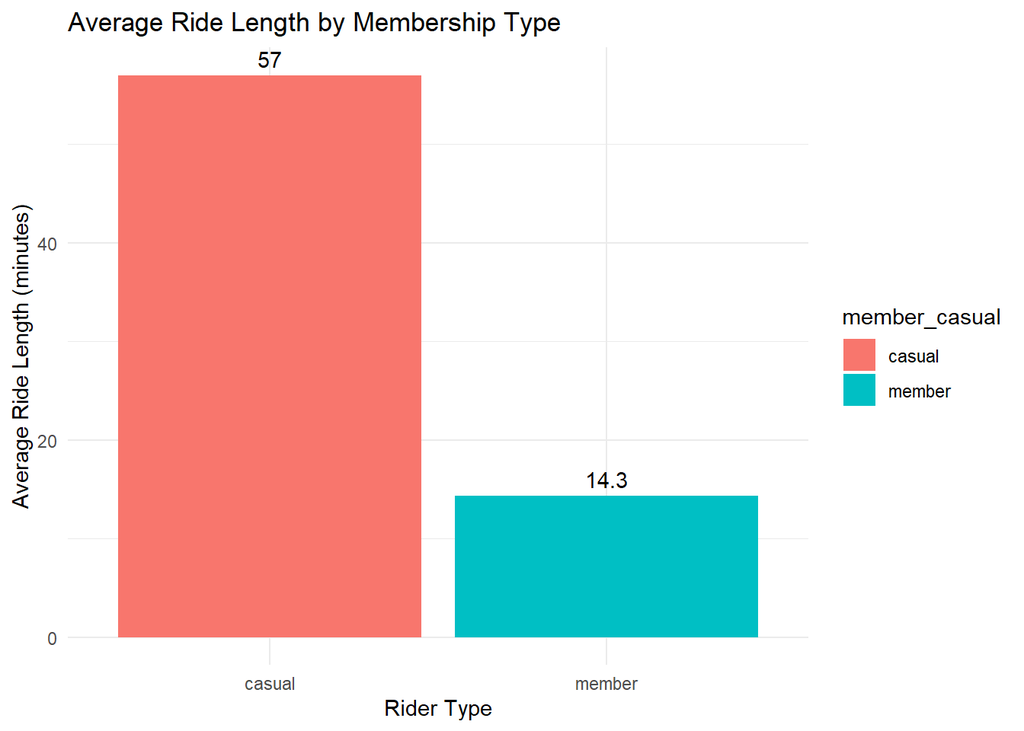

```r
# sum average ride length by membership type
average_ride_length <- df %>%
  group_by(member_casual) %>%
  summarise(average_minutes = mean(ride_length, na.rm = TRUE))

# bar chart of average ride length
ggplot(average_ride_length, aes(x = member_casual, y = average_minutes, fill = member_casual)) +
  geom_bar(stat = "identity") +
  geom_text(aes(label = round(average_minutes, 1)), vjust = -0.5) +
  theme_minimal() +
  labs(title = "Average Ride Length by Membership Type", y = "Average Ride Length (minutes)", x = "Rider Type")
```

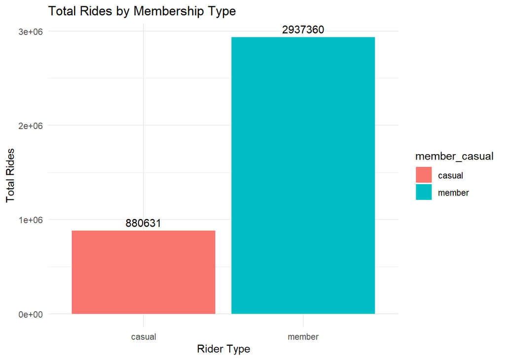

```r
# bar chart 0f ride frequency per user
ggplot(df, aes(x = member_casual, fill = member_casual)) +
  geom_bar() +
  geom_text(stat = "count", aes(label = ..count..), vjust = -0.5) +
  labs(title = "Total Rides by Membership Type",
       x = "Rider Type",
       y = "Total Rides") +
  theme_minimal()
```

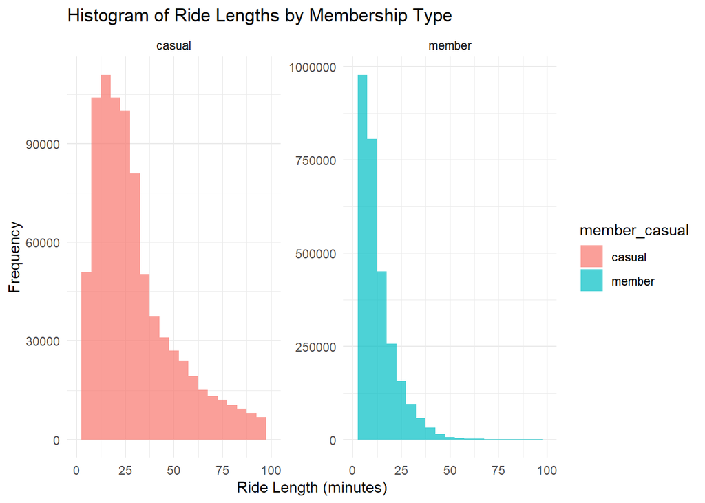

```r
# histograms of ride length per user type
ggplot(df, aes(x = ride_length, fill = member_casual)) +
  geom_histogram(binwidth = 5, alpha = 0.7) +
  facet_wrap(~ member_casual, scales = "free_y") +
  labs(title = "Histogram of Ride Lengths by Membership Type",
       x = "Ride Length (minutes)",
       y = "Frequency") +
  theme_minimal() +
  # scale_fill_manual(values = c("member" = "blue", "casual" = "red")) +
  xlim(0,100)
```

Members ride more frequently for shorter duration (probably commuting).

Casuals ride longer, enough to beat members for total minutes on a bicycle.

## Time and Ridership

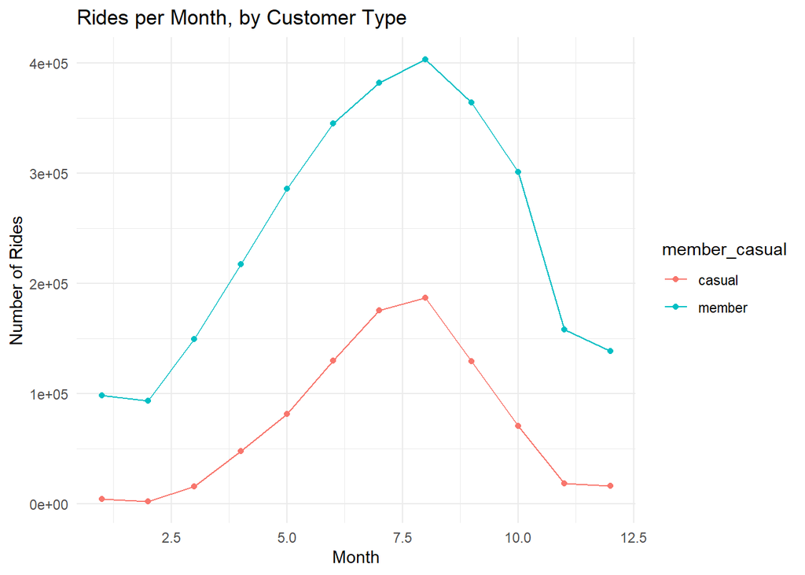

```r
# line chart of rides per month
df %>%
  group_by(month, member_casual) %>%
  summarise(rides = n()) %>%
  ggplot(aes(x = month, y = rides, color = member_casual, group = member_casual)) +
  geom_line() +
  geom_point() +
  theme_minimal() +
  labs(title = "Rides per Month, by Customer Type", x = "Month", y = "Number of Rides")
```

Peak in August, unsurprisingly.

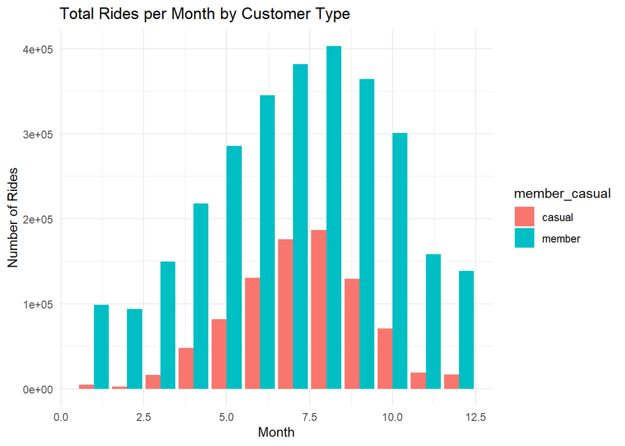

```r
# bar chart of rides per month
df %>%
  group_by(month, member_casual) %>%
  summarise(rides = n()) %>%
  ggplot(aes(x = month, y = rides, fill = member_casual)) +
  geom_bar(stat = "identity", position = "dodge") +
  theme_minimal() +
  labs(title = "Total Rides per Month by Customer Type", x = "Month", y = "Number of Rides")
```

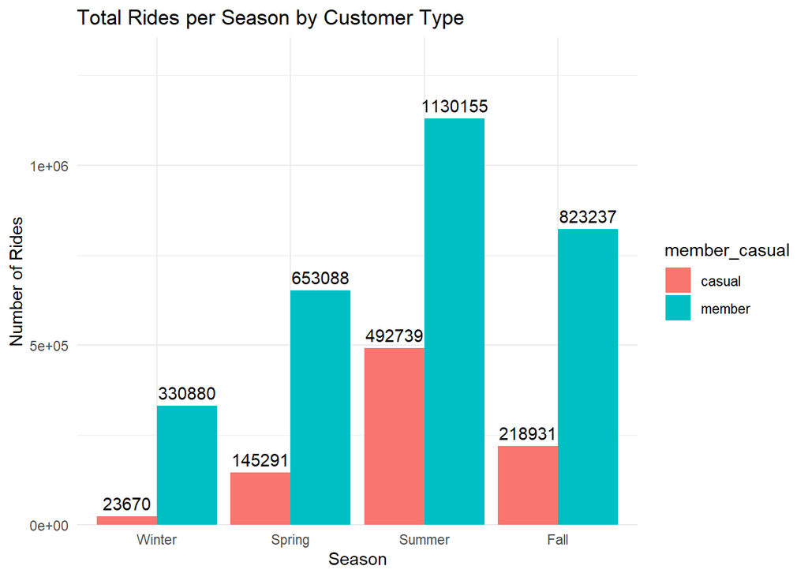

```r
# rides per season
df %>%
  mutate(season = factor(season, levels = c("Winter", "Spring", "Summer", "Fall"))) %>%
  group_by(season, member_casual) %>%
  summarise(rides = n()) %>%
  ggplot(aes(x = season, y = rides, fill = member_casual)) +
  geom_bar(stat = "identity", position = "dodge") +
  geom_text(aes(label = rides), vjust = -0.5, position = position_dodge(0.9)) +
  theme_minimal() +
  labs(title = "Total Rides per Season by Customer Type", x = "Season", y = "Number of Rides") +
  scale_y_continuous(expand = expansion(mult = c(0, 0.2)))
```

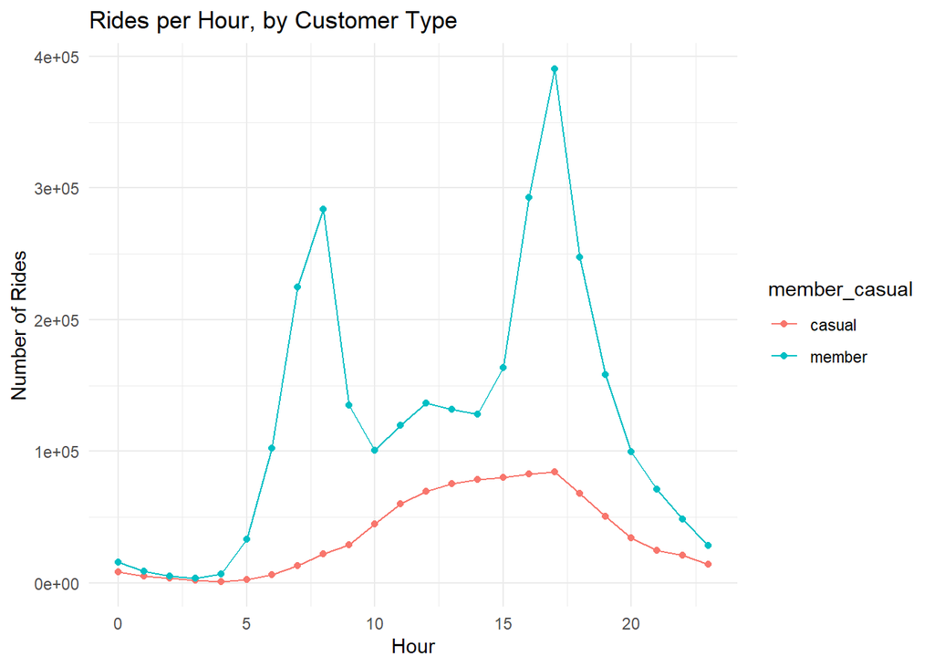

```r
# line chart of rides per hour
df %>%
  group_by(hour, member_casual) %>%
  summarise(rides = n()) %>%
  ggplot(aes(x = hour, y = rides, color = member_casual, group = member_casual)) +
  geom_line() +
  geom_point() +
  theme_minimal() +
  labs(title = "Rides per Hour, by Customer Type", x = "Hour", y = "Number of Rides")
```

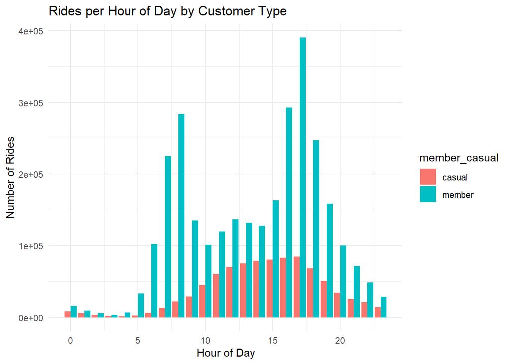

```r
# bar chart of rides per hour
df %>%
  group_by(hour, member_casual) %>%
  summarise(rides = n()) %>%
  ggplot(aes(x = hour, y = rides, fill = member_casual)) +
  geom_bar(stat = "identity", position = "dodge") +
  theme_minimal() +
  labs(title = "Rides per Hour of Day by Customer Type", x = "Hour of Day", y = "Number of Rides")
```

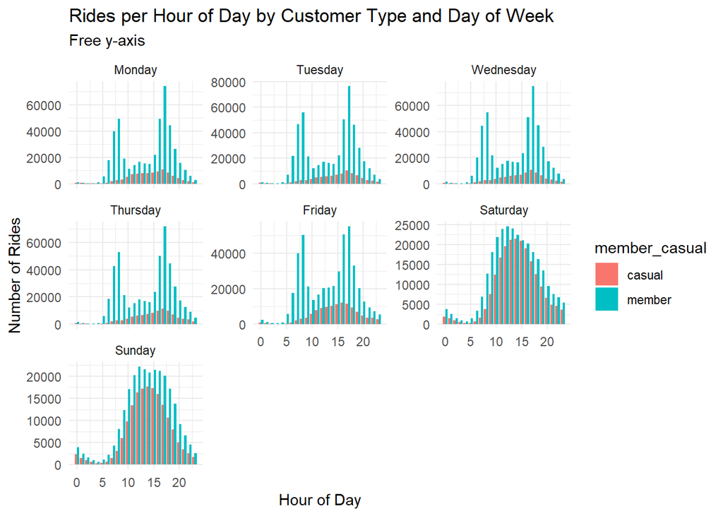

```r
# bar chart of rides per hour by day of week, free y-axis
df %>%
  mutate(day_of_week = factor(day_of_week, levels = c("Monday", "Tuesday", "Wednesday", "Thursday", "Friday", "Saturday", "Sunday"))) %>%
  group_by(hour, member_casual, day_of_week) %>%
  summarise(rides = n()) %>%
  ggplot(aes(x = hour, y = rides, fill = member_casual)) +
  geom_bar(stat = "identity", position = "dodge") +
  facet_wrap(~ day_of_week, scales = "free_y") +
  theme_minimal() +
  labs(title = "Rides per Hour of Day by Customer Type and Day of Week", subtitle = "Free y-axis", x = "Hour of Day", y = "Number of Rides")
```

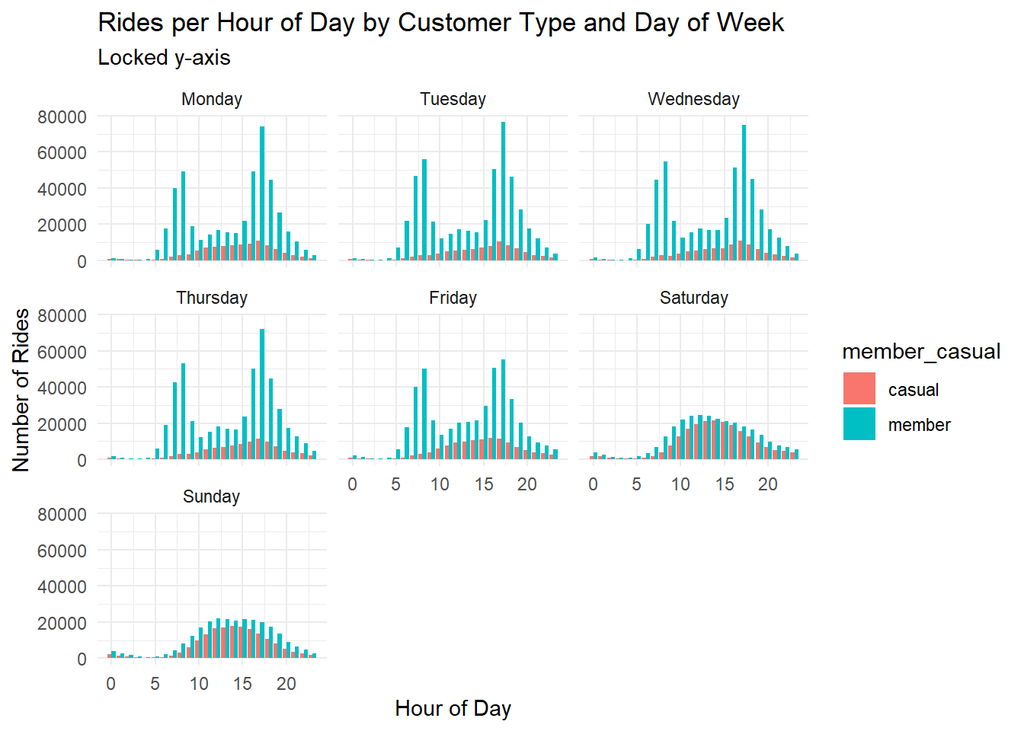

```r
# bar chart of rides per hour by day of week, locked y-axis
df %>%
  mutate(day_of_week = factor(day_of_week, levels = c("Monday", "Tuesday", "Wednesday", "Thursday", "Friday", "Saturday", "Sunday"))) %>%
  group_by(hour, member_casual, day_of_week) %>%
  summarise(rides = n()) %>%
  ggplot(aes(x = hour, y = rides, fill = member_casual)) +
  geom_bar(stat = "identity", position = "dodge") +
  facet_wrap(~ day_of_week) +
  theme_minimal() +
  labs(title = "Rides per Hour of Day by Customer Type and Day of Week", subtitle = "Locked y-axis", x = "Hour of Day", y = "Number of Rides")
```

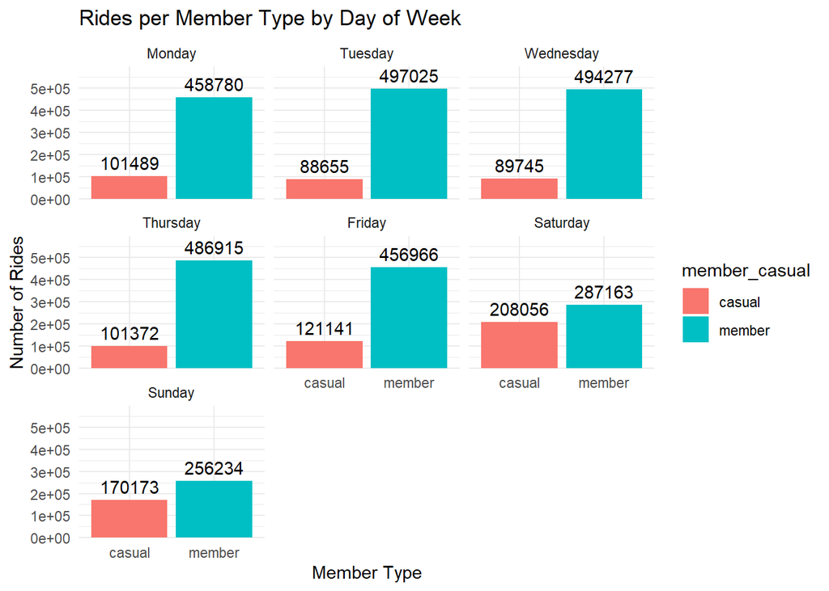

```r
# bar chart of rides / member_casual / day of week
df %>%
  mutate(day_of_week = factor(day_of_week, levels = c("Monday", "Tuesday", "Wednesday", "Thursday", "Friday", "Saturday", "Sunday"))) %>%
  group_by(member_casual, day_of_week) %>%
  summarise(rides = n()) %>%
  ggplot(aes(x = member_casual, y = rides, fill = member_casual)) +
  geom_bar(stat = "identity", position = "dodge") +
  geom_text(aes(label = rides), vjust = -0.5, position = position_dodge(0.9)) +
  facet_wrap(~ day_of_week) +
  theme_minimal() +
  labs(title = "Rides per Member Type by Day of Week", x = "Member Type", y = "Number of Rides") +
  scale_y_continuous(expand = expansion(mult = c(0, 0.2)))
```

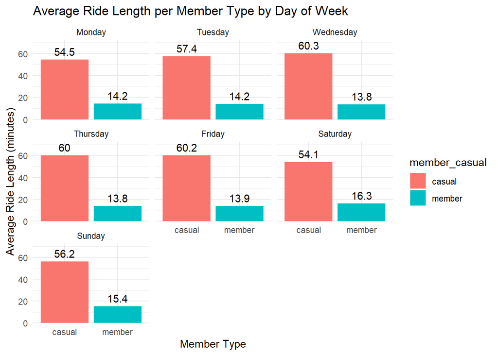

```r
# bar chart avg ride time / member_casual / day of week
df %>%
  mutate(day_of_week = factor(day_of_week, levels = c("Monday", "Tuesday", "Wednesday", "Thursday", "Friday", "Saturday", "Sunday"))) %>%
  group_by(member_casual, day_of_week) %>%
  summarise(avg_ride_length = mean(ride_length, na.rm = TRUE)) %>%
  ggplot(aes(x = member_casual, y = avg_ride_length, fill = member_casual)) +
  geom_bar(stat = "identity", position = "dodge") +
  geom_text(aes(label = round(avg_ride_length, 1)), vjust = -0.5, position = position_dodge(0.9)) +
  facet_wrap(~ day_of_week) +
  theme_minimal() +
  labs(title = "Average Ride Length per Member Type by Day of Week", x = "Member Type", y = "Average Ride Length (minutes)") +
  scale_y_continuous(expand = expansion(mult = c(0, 0.2)))
```

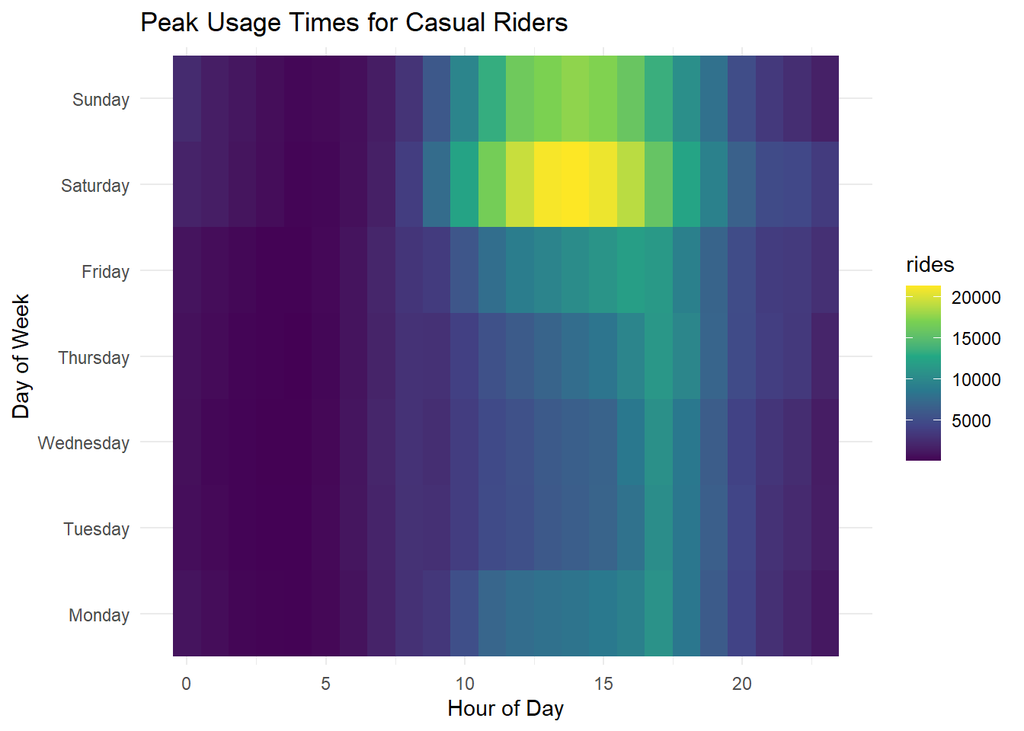

```r
# aggregate casual rider counts by hour and day of the week
casual_peak_times <- df %>%
  mutate(day_of_week = factor(day_of_week, levels = c("Monday", "Tuesday", "Wednesday", "Thursday", "Friday", "Saturday", "Sunday"))) %>%  filter(member_casual == "casual") %>%
  group_by(day_of_week, hour) %>%
  summarise(rides = n(), .groups = "drop")

# heatmap of peak times for casual riders
ggplot(casual_peak_times, aes(x = hour, y = day_of_week, fill = rides)) +
  geom_tile() +
  scale_fill_viridis_c() +
  theme_minimal() +
  labs(title = "Peak Usage Times for Casual Riders", x = "Hour of Day", y = "Day of Week")
```

Peak time is Saturday afternoon, followed by Sunday afternoon. Unsurprising.

## Stations

```r
library(sf)
library(ggspatial)
```

```
## Zoom: 12
```

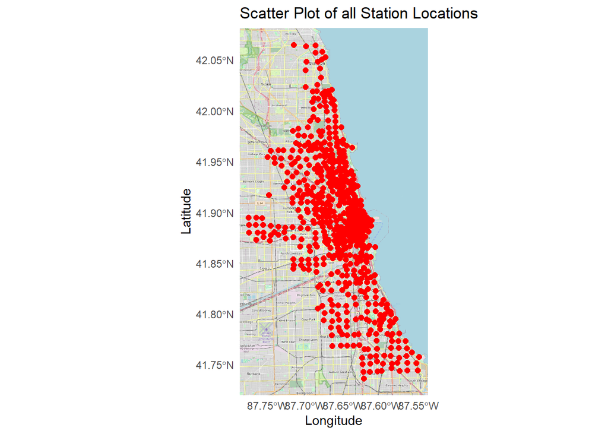

```r
# convert the stations_2020 data frame to an sf object
stations_sf <- stations %>% drop_na() %>% st_as_sf(coords = c("longitude", "latitude"), crs = 4326)

# plot the map with the station locations
ggplot() +
  annotation_map_tile(type = "osm", zoom = 12) +
  geom_sf(data = stations_sf, color = "red", size = 2) +
  labs(title = "Scatter Plot of all Station Locations",
       x = "Longitude",
       y = "Latitude") +
  theme_minimal()
```

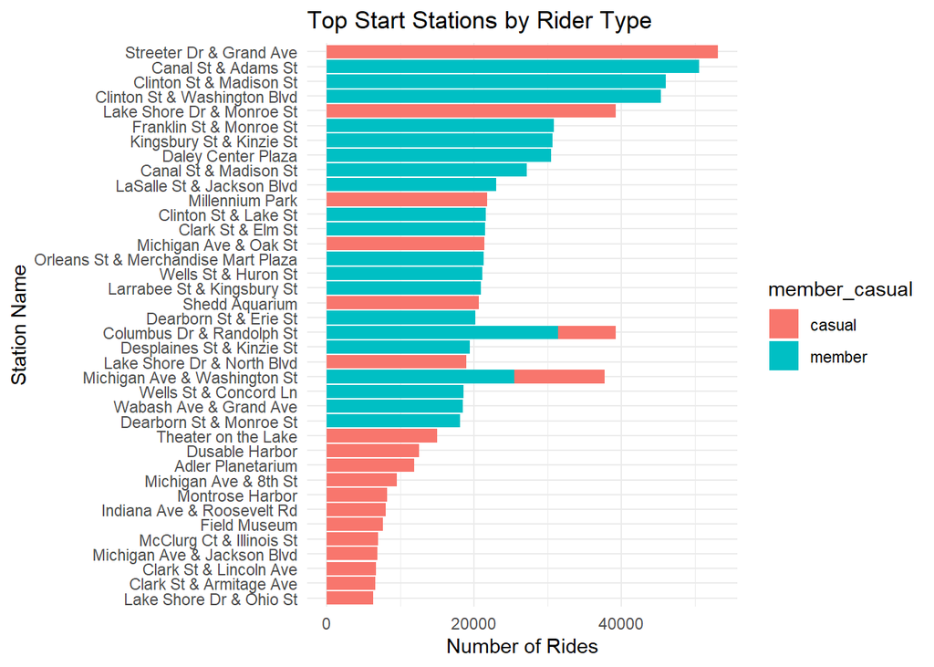

```r
# bar chart: top start stations
df %>%
  count(start_station_name, member_casual, sort = TRUE) %>%
  group_by(member_casual) %>%
  top_n(20, n) %>%
  ggplot(aes(x = reorder(start_station_name, n), y = n, fill = member_casual)) +
  geom_col() +
  coord_flip() +
  theme_minimal() +
  labs(title = "Top Start Stations by Rider Type", x = "Station Name", y = "Number of Rides")
```

Those two bars are weird and don’t seem right. I am guessing that if I knew the geography of Chicago, the casual / member stations would be more illuminating. “Milleniumn Park”, “Shedd Aquarium”, “Theater on the Lake”, “Dusable Harbor”, and “Adler Planetarium” sound like destinations for the occasional bike rider.

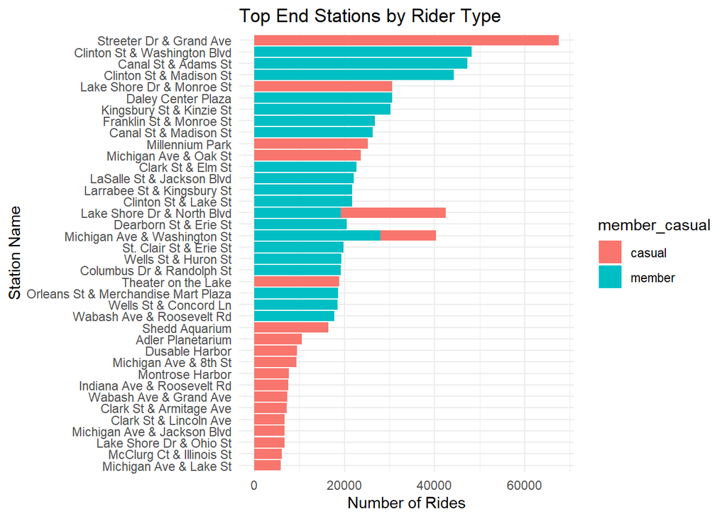

```r
# bar chart: top end stations
df %>%
  count(end_station_name, member_casual, sort = TRUE) %>%
  group_by(member_casual) %>%
  top_n(20, n) %>%
  ggplot(aes(x = reorder(end_station_name, n), y = n, fill = member_casual)) +
  geom_col() +
  coord_flip() +
  theme_minimal() +
  labs(title = "Top End Stations by Rider Type", x = "Station Name", y = "Number of Rides")
```

```r
# most popular start stations
top_stations <- df %>%
  count(start_station_name, member_casual, sort = TRUE) %>%
  group_by(member_casual) %>%
  top_n(20, n)

print(top_stations)
```

```
## # A tibble: 40 × 3
## # Groups:   member_casual [2]
##    start_station_name           member_casual     n
##    <chr>                        <chr>         <int>
##  1 Streeter Dr & Grand Ave      casual        53104
##  2 Canal St & Adams St          member        50575
##  3 Clinton St & Madison St      member        45990
##  4 Clinton St & Washington Blvd member        45378
##  5 Lake Shore Dr & Monroe St    casual        39238
##  6 Columbus Dr & Randolph St    member        31370
##  7 Franklin St & Monroe St      member        30832
##  8 Kingsbury St & Kinzie St     member        30654
##  9 Daley Center Plaza           member        30423
## 10 Canal St & Madison St        member        27138
## # ℹ 30 more rows
```

```r
# most popular end stations
top_stations <- df %>%
  count(end_station_name, member_casual, sort = TRUE) %>%
  group_by(member_casual) %>%
  top_n(20, n)

print(top_stations)
```

```
## # A tibble: 40 × 3
## # Groups:   member_casual [2]
##    end_station_name             member_casual     n
##    <chr>                        <chr>         <int>
##  1 Streeter Dr & Grand Ave      casual        67585
##  2 Clinton St & Washington Blvd member        48193
##  3 Canal St & Adams St          member        47330
##  4 Clinton St & Madison St      member        44307
##  5 Lake Shore Dr & Monroe St    casual        30673
##  6 Daley Center Plaza           member        30631
##  7 Kingsbury St & Kinzie St     member        30212
##  8 Michigan Ave & Washington St member        27934
##  9 Franklin St & Monroe St      member        26763
## 10 Canal St & Madison St        member        26339
## # ℹ 30 more rows
```

```r
# Leaflet: popular start stations with cleaned data
library(leaflet)
```

```r
# remove rows with missing latitude or longitude values
cleaned_data <- df %>%
  filter(!is.na(start_lng) & !is.na(start_lat))

# get a sample - too many rows, it crashes my computer to plot all 4 million
set.seed(123)  # for reproducibility of sample
cleaned_data <- cleaned_data %>% sample_n(1000)

# plot sampled stations
leaflet(data = cleaned_data) %>%
  addTiles() %>%
  addMarkers(lng = ~start_lng, lat = ~start_lat, clusterOptions = markerClusterOptions())
```

[interactive chart not shown]

```r
# Leaflet: popular end stations with cleaned data
library(leaflet)

# remove rows with missing latitude or longitude values
cleaned_data <- df %>%
  filter(!is.na(end_lng) & !is.na(end_lat))

# get a sample - too many rows, it crashes my computer to plot all 4 million
set.seed(123)  # for reproducibility of sample
cleaned_data <- cleaned_data %>% sample_n(1000)

# plot sampled stations
leaflet(data = cleaned_data) %>%
  addTiles() %>%
  addMarkers(lng = ~end_lng, lat = ~end_lat, clusterOptions = markerClusterOptions())
```

[interactive chart not shown]

```
## Zoom: 12
```

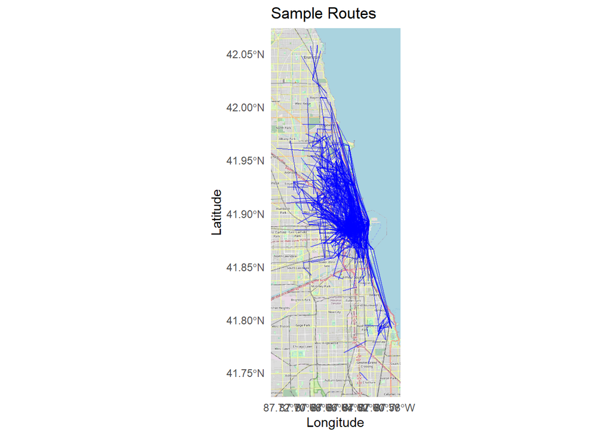

```r
library(sf)
library(ggspatial)

# sample data
set.seed(123)  # for reproducibility
cleaned_data <- df %>% sample_n(1000)

# create linestring geometries for routes
routes <- cleaned_data %>%
  drop_na(start_lng, start_lat, end_lng, end_lat) %>%
  rowwise() %>%
  mutate(geometry = st_sfc(st_linestring(matrix(c(start_lng, start_lat, end_lng, end_lat), ncol = 2, byrow = TRUE)), crs = 4326)) %>%
  st_as_sf()

# plot routes
ggplot() +
  annotation_map_tile(type = "osm", zoom = 12) +
  geom_sf(data = routes, aes(geometry = geometry), color = "blue", size = 0.5, alpha = 0.5) +
  labs(title = "Sample Routes",
       x = "Longitude",
       y = "Latitude") +
  theme_minimal()
```

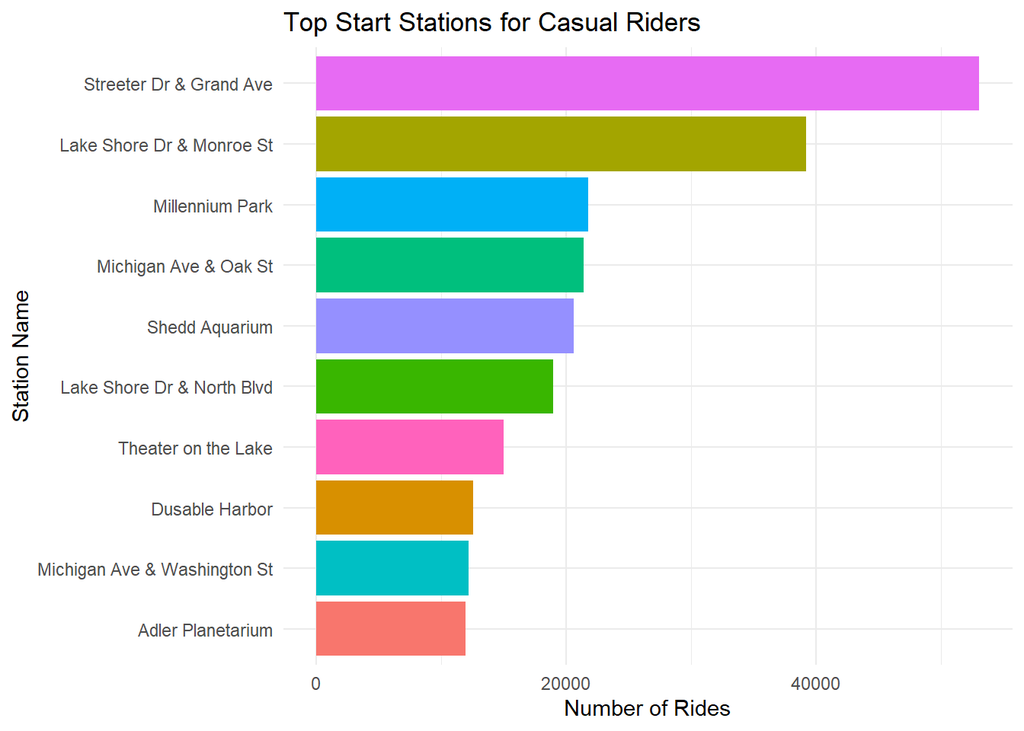

```r
# aggregate casual rider counts by station
casual_peak_stations <- df %>%
  filter(member_casual == "casual") %>%
  count(start_station_name, sort = TRUE) %>%
  top_n(10, n)

# bar chart of top stations for casual riders
ggplot(casual_peak_stations, aes(x = reorder(start_station_name, n), y = n, fill = start_station_name)) +
  geom_col(show.legend = FALSE) +
  coord_flip() +
  theme_minimal() +
  labs(title = "Top Start Stations for Casual Riders", x = "Station Name", y = "Number of Rides")
```

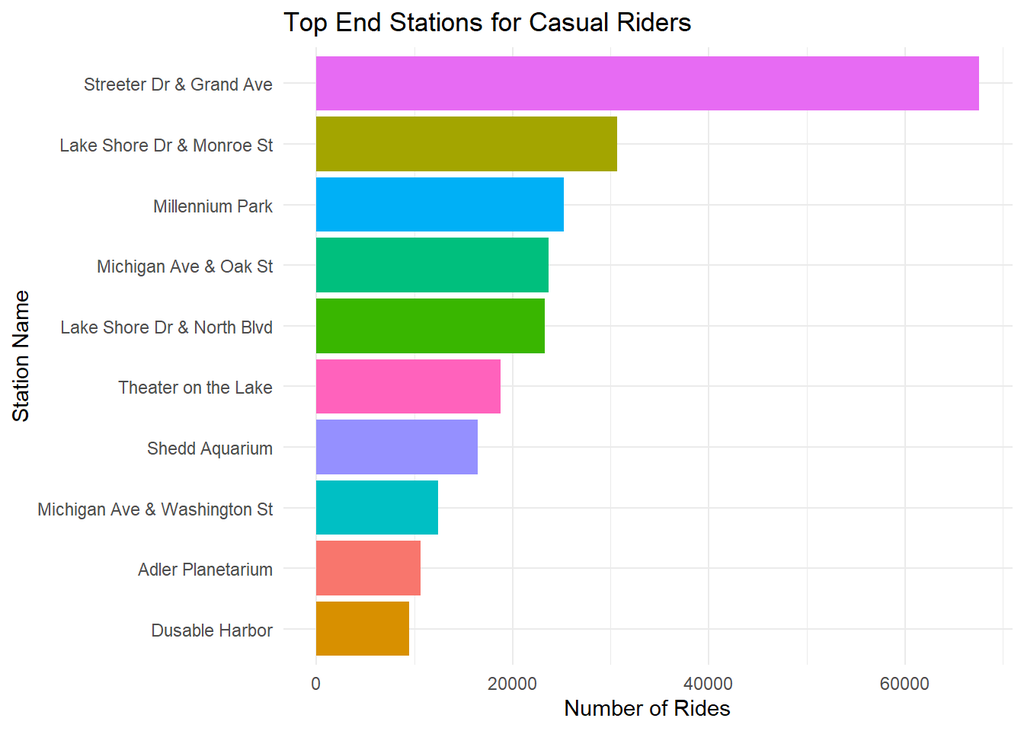

```r
# aggregate casual rider counts by station
casual_peak_stations <- df %>%
  filter(member_casual == "casual") %>%
  count(end_station_name, sort = TRUE) %>%
  top_n(10, n)

# bar chart of top stations for casual riders
ggplot(casual_peak_stations, aes(x = reorder(end_station_name, n), y = n, fill = end_station_name)) +
  geom_col(show.legend = FALSE) +
  coord_flip() +
  theme_minimal() +
  labs(title = "Top End Stations for Casual Riders", x = "Station Name", y = "Number of Rides")
```

## Demographics

Remember, this is member rides and casual rides, so member’s presumably will be over respresented.

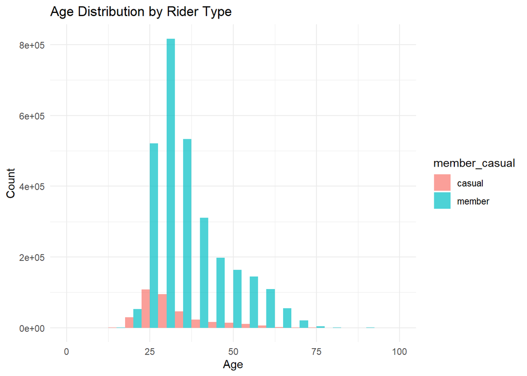

```r
# age distribution
ggplot(df, aes(x = 2020 - birthyear, fill = member_casual)) +
  geom_histogram(binwidth = 5, alpha = 0.7, position = "dodge") +
  # stat_bin(binwidth = 5, geom = "text", aes(label = ..count..), vjust = -0.5, position = position_dodge(5)) +
  theme_minimal() +
  labs(title = "Age Distribution by Rider Type", x = "Age", y = "Count") +
  xlim(0, 100)
```

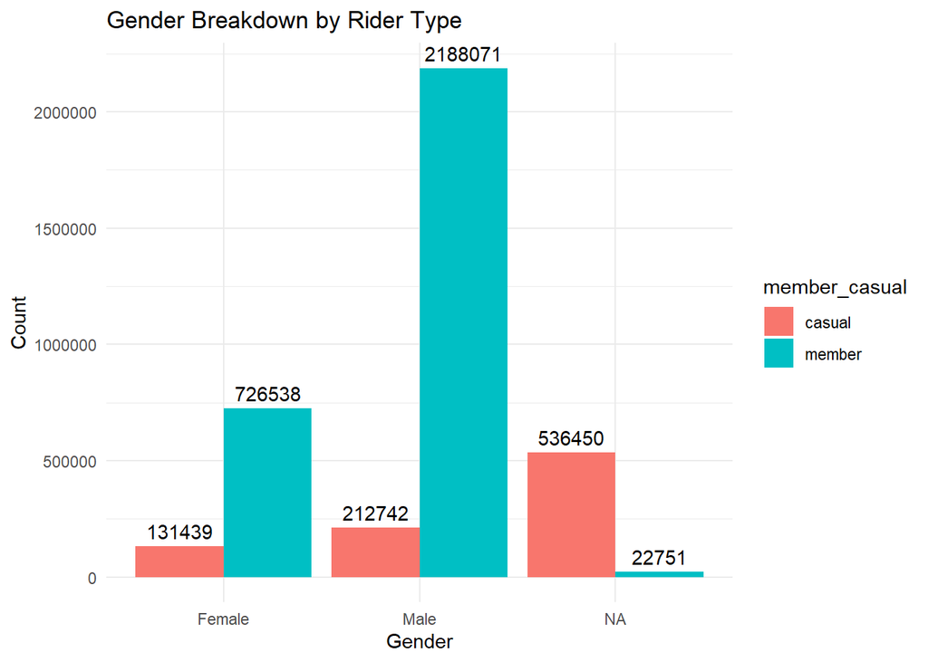

```r
# gender split
ggplot(df, aes(x = gender, fill = member_casual)) +
  geom_bar(position = "dodge") +
  geom_text(stat = "count", aes(label = ..count..), vjust = -0.5, position = position_dodge(0.9)) +
  theme_minimal() +
  labs(title = "Gender Breakdown by Rider Type", x = "Gender", y = "Count")
```